# Educenter Hugo | [Demo](https://demo.gethugothemes.com/educenter) | [Page Speed (86%)](https://lighthouse-dot-webdotdevsite.appspot.com//lh/html?url=https%3A%2F%2Fdemo.gethugothemes.com%2Feducenter%2F)

[figure not shown]

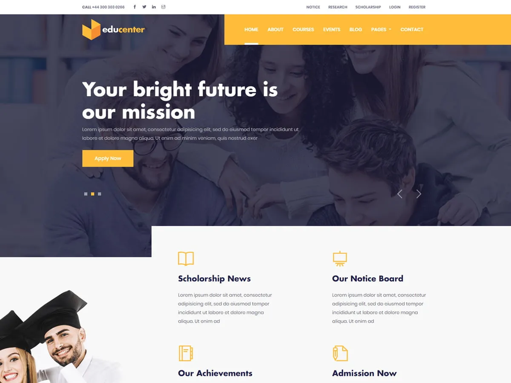

## Features

- Multiple language support (Fr, En)
- Google analytics support
- CSS and Js bundle with hugo pipe
- Netlify settings predefine
- Forestry cms pre-configured
- Multiple author available
- Contact form Support
- Mailchimp integrate
- GDPR consent enable
- Google map support
- Top header customization
- Taxonomy or category
- Google page speed optimized ( 86% )
- Open graph meta tag
- Twitter card meta tag

## Local development

```bash
# clone the repository
git clone git@github.com:themefisher/educenter-hugo.git

# cd in the project directory
$ cd educenter-hugo/exampleSite/

# Start local dev server
$ hugo server --themesDir ../..
```

Or Check out [Full Documentation](https://docs.gethugothemes.com/educenter/?ref=github).

## Content Management System

[figure not shown]

This project has been pre-configured to work with [Forestry](https://forestry.io) a git-based CMS, [import your repository in Forestry](https://app.forestry.io/quick-start?repo=themefisher/educenter-hugo&engine=hugo&version=0.87.0) and you will be able to edit and preview your site ✨.

[figure not shown]

## Prefer a video? (Hugo + Netlify + Forestry)

Build your website with **Educenter Hugo** theme by following these easy steps (No Coding Required!) [Video Tutorial](https://youtu.be/ResipmZmpDU).

## Reporting Issues

We use GitHub Issues as the official bug tracker for the Educenter Template. Please Search [existing issues](https://github.com/themefisher/educenter-hugo/issues). Someone may have already reported the same problem. If your problem or idea has not been addressed yet, feel free to [open a new issue](https://github.com/themefisher/educenter-hugo/issues).

## License

Copyright © Designed by [Themefisher](https://themefisher.com) & Developed by [Gethugothemes](https://gethugothemes.com)

**Code License:** Released under the [MIT](https://github.com/themefisher/educenter-hugo/blob/master/LICENSE) license.

**Image license:** The images are only for demonstration purposes. They have their licenses. We don’t have permission to share those images.

## Special Thanks

- [Bootstrap](https://getbootstrap.com)
- [Jquery](https://jquery.com)
- [Themify Icons](https://themify.me/themify-icons)
- [Slick Slider](https://kenwheeler.github.io/slick/)
- [Venobox](https://veno.es/venobox/)
- [Filterizr](https://yiotis.net/filterizr/)
- [Google Fonts](https://fonts.google.com/)
- [All Contributors](https://github.com/themefisher/educenter-hugo/graphs/contributors)

## Hire Us

Besides developing unique, blazing-fast Hugo themes, we also provide customized services. We specialize in creating affordable, high-quality static websites based on Hugo.

If you need to customize the theme or complete website development from scratch, you can hire us. **Check Our [Services](https://gethugothemes.com/services/?utm_source=educenter_github&utm_medium=referral&utm_campaign=github_theme_readme)**

## Premium Themes By Us

[figure not shown]

[figure not shown]

[figure not shown]

**Get 50+ Premium Hugo Themes Bundle**

**Bizcraft**

**Bexer**